# Challenge-2

Misra Anandita

2023-09-21

**Welcome!** Hope you have watched the lecture videos and followed the instructions in code-along. Go through the steps described below, *carefully*. It is totally fine to get stuck - **ASK FOR HELP**; reach out to your friends, TAs, or the discussion forum on Canvas.

Here is what you have to do,

1. **Pair** with a neighbor and work
2. **Download** the `Challenge-2.Rmd` and `playlist_data.csv` files from Canvas
3. **Move** the downloaded files to the folder, “Week-2”
4. **Set** it as the working directory
5. **Edit** content wherever indicated
6. **Remember** to set `eval=TRUE` after completing the code to generate the output
7. **Ensure** that `echo=TRUE` so that the code is rendered in the final document
8. **Inform** the tutor/instructor upon completion
9. **Submit** the document on Canvas after they approve
10. **Attendance** will be marked only after submission
11. Once again, **do not hesitate** to reach out to the tutors/instructor, if you are stuck

# I. Exploring music preferences

### A. Background

Imagine that you have been hired as a data analyst by a radio station to analyze music preferences of their DJs. They have provided you with a dataset, `playlist_data.csv`, containing information about DJs, their preferred music genres, song titles, and ratings.

Using the data-set you are required to complete some tasks that are listed subsequently. All these tasks are based on the concepts taught in the video lectures. The questions may not be entirely covered in the lectures; To complete them, you are encouraged to use Google and the resources therein.

### B.Tasks

#### Task-1

In the lecture, we used two data-sets, `starwars` and `anscombe's quartet` that were readily available with the packages, `tidyverse` and `Tmisc`, respectively. When we have to use custom-made data-sets or the ones like we downloaded from Canvas, we have to import it using the R commands before using them. All the questions below are related to this task.

**Question 1.1:** What does the term “CSV” in `playlist_data.csv` stand for, and why is it a popular format for storing tabular data?

**Solution:** The term CSV stands for “Comma-Separated Values”. It is a popular format for storing tabular data since they are plain text files- it is easy to read and write and it has a very intuitive structure since there are rows of data which is simply separated by commas, hence the name. They are popular because of their simplicity and compatibility to work well with other systems.  
**Question 1.2:** load the `tidyverse` package to work with `.csv` files in R.

**Solution:**

```r
# Load the necessary package to work with CSV files in R.
library("tidyverse")
```

**Question 1.3:** Import the data-set, `playlist_data.csv`

**Solution:**

```r
# Import the "playlist_data.csv" dataset into R

read_csv("playlist_data.csv")
```

```
## # A tibble: 26 × 7
##    DJ_Name Music_Genre Rating Experience     Age Location Plays_Per_Week
##    <chr>   <chr>        <dbl> <chr>        <dbl> <chr>             <dbl>
##  1 DJ A    Pop            4.2 Advanced        28 City X               80
##  2 DJ B    Rock           3.8 Intermediate    24 City Y               60
##  3 DJ C    Electronic     4.5 Advanced        30 City Z              100
##  4 DJ D    Pop            4   Intermediate    22 City X               70
##  5 DJ E    Electronic     4.8 Advanced        27 City Y               90
##  6 DJ F    Rock           3.6 Intermediate    25 City Z               55
##  7 DJ G    Pop            4.3 Advanced        29 City X               85
##  8 DJ H    Electronic     4.1 Intermediate    23 City Y               75
##  9 DJ I    Rock           3.9 Advanced        31 City Z               70
## 10 DJ J    Pop            4.4 Intermediate    26 City X               95
## # ℹ 16 more rows
```

**Question 1.4:** Assign the data-set to a variable, `playlist_data`

**Solution:**

```r
# Assign the variable to a dataset

playlist_data <- read_csv("playlist_data.csv")
```

*From now on, you can use the name of the variable to view the contents of the data-set*

**Question 1.5:** Get more information about `read_csv()` command and provide a screenshot of the information displayed in the “Help” tab of the “Files” pane

**Solution:**

```r
# More information about the R command, complete the code

?read_csv()
```

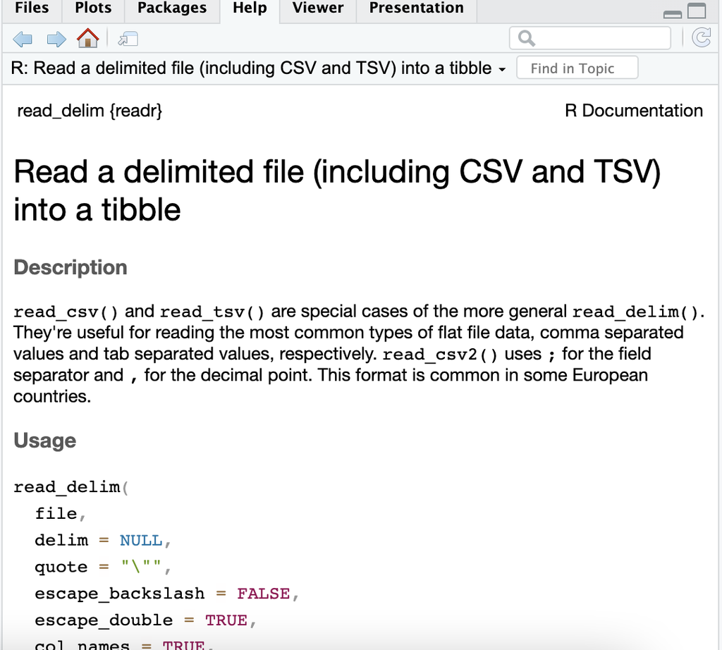

```r
knitr::include_graphics("read_csv_screenshot.png")
```

**Question 1.6:** What does the `skip` argument in the read_csv() function do?

**Solution:** When we use the ‘skip’ argument in the read_csv() function, the function will ignore or skip upto the specified number of lines from the file beginning. It will then read data from the line that is immediately after the skipped lines. So, we specify the file and the number of lines to skip with this argument in the read_csv() function.

**Question 1.7:** Display the contents of the data-set

**Solution:**

```r
# Type the name of the variable, to see what it contains
playlist_data
```

```
## # A tibble: 26 × 7
##    DJ_Name Music_Genre Rating Experience     Age Location Plays_Per_Week
##    <chr>   <chr>        <dbl> <chr>        <dbl> <chr>             <dbl>
##  1 DJ A    Pop            4.2 Advanced        28 City X               80
##  2 DJ B    Rock           3.8 Intermediate    24 City Y               60
##  3 DJ C    Electronic     4.5 Advanced        30 City Z              100
##  4 DJ D    Pop            4   Intermediate    22 City X               70
##  5 DJ E    Electronic     4.8 Advanced        27 City Y               90
##  6 DJ F    Rock           3.6 Intermediate    25 City Z               55
##  7 DJ G    Pop            4.3 Advanced        29 City X               85
##  8 DJ H    Electronic     4.1 Intermediate    23 City Y               75
##  9 DJ I    Rock           3.9 Advanced        31 City Z               70
## 10 DJ J    Pop            4.4 Intermediate    26 City X               95
## # ℹ 16 more rows
```

**Question 1.8:** Assume you have a CSV file named `sales_data.csv` containing information about sales transactions. How would you use the `read_csv()` function to import this file into R and store it in a variable named `sales_data`?

**Solution:**

```r
# No output is required for this code
# Only the list of commands that execute the task mentioned in the question are required

read_csv("sales_data.csv")
sales_data <- read_csv("sales_data.csv)")
```

#### Task-2

After learning to import a data-set, let us explore the contents of the data-set through the following questions

**Question 2.1:** Display the first few rows of the data-set to get an overview of its structure

**Solution:**

```r
# Type the name of the variable we assigned the data-set to
head(playlist_data)
```

```
## # A tibble: 6 × 7
##   DJ_Name Music_Genre Rating Experience     Age Location Plays_Per_Week
##   <chr>   <chr>        <dbl> <chr>        <dbl> <chr>             <dbl>
## 1 DJ A    Pop            4.2 Advanced        28 City X               80
## 2 DJ B    Rock           3.8 Intermediate    24 City Y               60
## 3 DJ C    Electronic     4.5 Advanced        30 City Z              100
## 4 DJ D    Pop            4   Intermediate    22 City X               70
## 5 DJ E    Electronic     4.8 Advanced        27 City Y               90
## 6 DJ F    Rock           3.6 Intermediate    25 City Z               55
```

**Question 2.2:** Display all the columns of the variable stacked one below another

**Solution:**

```r
# Stack columns of playlist_data
glimpse(playlist_data)
```

```
## Rows: 26
## Columns: 7
## $ DJ_Name        <chr> "DJ A", "DJ B", "DJ C", "DJ D", "DJ E", "DJ F", "DJ G",…
## $ Music_Genre    <chr> "Pop", "Rock", "Electronic", "Pop", "Electronic", "Rock…
## $ Rating         <dbl> 4.2, 3.8, 4.5, 4.0, 4.8, 3.6, 4.3, 4.1, 3.9, 4.4, 4.6, …
## $ Experience     <chr> "Advanced", "Intermediate", "Advanced", "Intermediate",…
## $ Age            <dbl> 28, 24, 30, 22, 27, 25, 29, 23, 31, 26, 32, 28, 29, 25,…
## $ Location       <chr> "City X", "City Y", "City Z", "City X", "City Y", "City…
## $ Plays_Per_Week <dbl> 80, 60, 100, 70, 90, 55, 85, 75, 70, 95, 110, 75, 60, 8…
```

**Question 2.3:** How many columns are there in the dataset?

**Solution:**

```r
# Number of columns
ncol(playlist_data)
```

```
## [1] 7
```

**Question 2.4:** What is the total count of DJs?

**Solution:**

```r
# Number of DJs
nrow(playlist_data)
```

```
## [1] 26
```

**Question 2.5:** Display all the location of all the DJs

**Solution:**

```r
# Location of DJs
playlist_data$Location
```

```
##  [1] "City X" "City Y" "City Z" "City X" "City Y" "City Z" "City X" "City Y"
##  [9] "City Z" "City X" "City Y" "City Z" "City X" "City Y" "City Z" "City X"
## [17] "City Y" "City Z" "City X" "City Y" "City Z" "City X" "City Y" "City Z"
## [25] "City X" "City Y"
```

**Question 2.6:** Display the age of the DJs

**Solution:**

```r
# Age of DJs
playlist_data$Age
```

```
##  [1] 28 24 30 22 27 25 29 23 31 26 32 28 29 25 31 26 27 24 29 23 28 24 30 22 27
## [26] 25
```

#### Task-3

Let us plot the data to get more insights about the DJs.

**Question 3.1:** Create a plot to visualize the relationship between DJs’ ages and their ratings.

**Solution:**

[figure not shown]

```r
# complete the code to generate the plot

ggplot(playlist_data) +
aes(x=Age,y=Rating)
```

**Question 3.2:** Label the x-axis as “Age” and the y-axis as “Rating.”

**Solution:**

[figure not shown]

```r
# complete the code to generate the plot

ggplot(playlist_data) +
aes(x=Age,y=Rating)+
  labs(x="Age", y="Rating")
```

**Question 3.3:** Represent data using points

**Solution:**

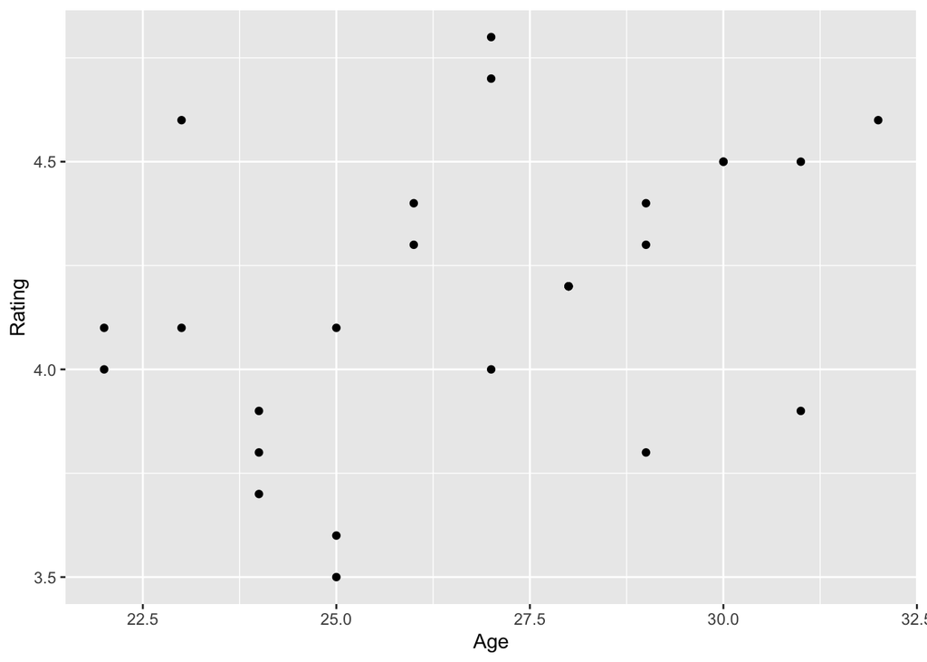

```r
# complete the code to generate the plot

ggplot(playlist_data) +
aes(x=Age,y=Rating)+
geom_point()+
  labs(x="Age", y="Rating")
```

**Question 3.4:** Can you change the points represented by dots/small circles to any other shape of your liking?

**Solution:**

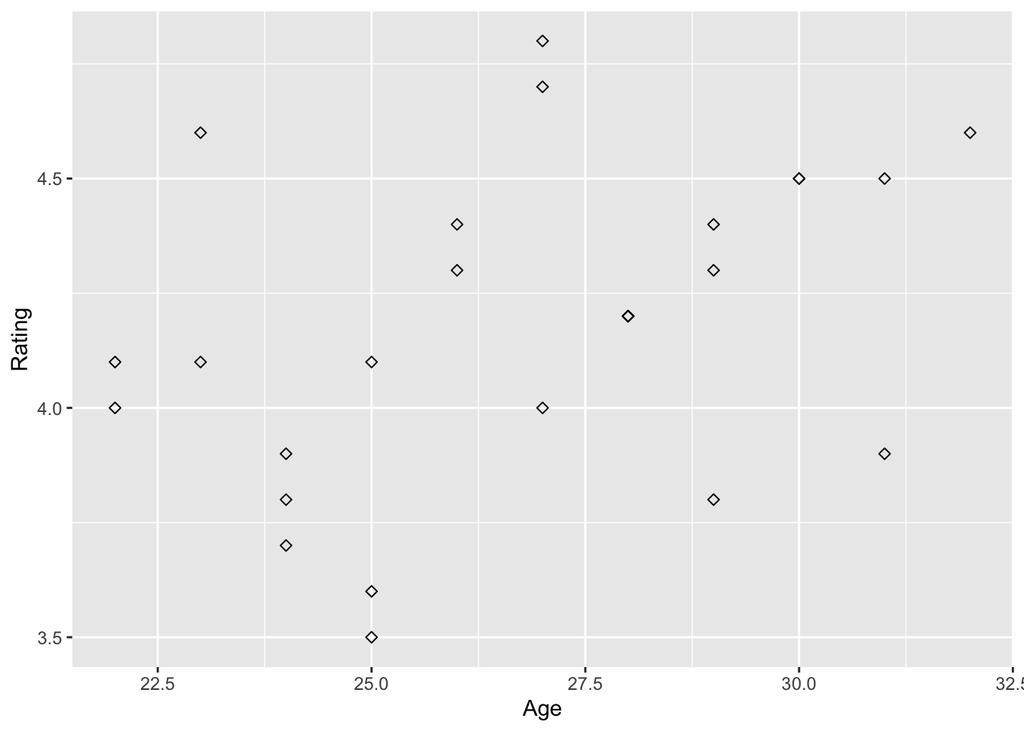

```r
# complete the code to generate the plot

ggplot(playlist_data) +
aes(x=Age,y=Rating)+
geom_point(shape=5)+
  labs(x="Age", y="Rating")
```

**Question 3.5:** Insert a suitable title and briefly provide your insights in the caption

**Solution:**

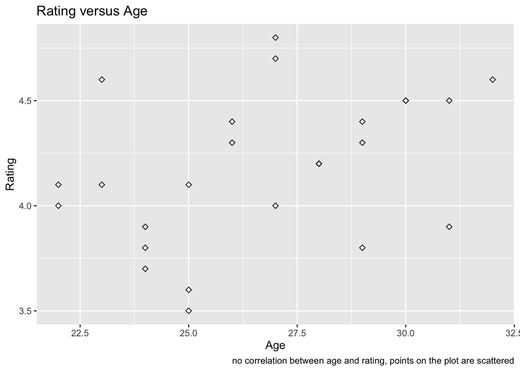

```r
# complete the code to generate the plot

ggplot(playlist_data) +
aes(x=Age,y=Rating)+
geom_point(shape=5)+
  labs(x="Age", y="Rating",
title="Rating versus Age", caption="no correlation between age and rating, points on the plot are scattered")
```